# R Markdown - Parameterized HTML Output

Nick Rohrbaugh

9/15/2020

# Anatomy of Rmd

This is an R Markdown document rendered as an HTML page. R Markdown documents are files that end in `.Rmd` and include a few different parts:

## The YAML header

The YAML header is the section at the very top of our file between the `---` symbols. This text doesn’t show up directly in our output, but it tells R Markdown how to render our document.

We can specify multiple output formats in our YAML header, like `html_document`, `pdf_document`, and `word_document`. We can also specify settings for these output formats, to do things like add a floating table of contents. And we can add things like a title, author, and date which may be automatically rendered depending on our output format.

## Code chunks

The most important part of our R Markdown document - our code! - lives in “chunks” throughout our document. These are the sections that start and end with three tick marks (```) and have a dark gray background in RStudio.

The first line of a code chunk also includes information in curly braces about the code and how its output should be displayed:

- The first and always required item is the language the code is in, e.g. `{r}` or `{python}`
- After the language comes an optional chunk label, e.g. `{r setup}`
- Finally and separated by a comma come any chunk options. These control the output of our code. A few useful ones include:
  - `eval`: whether to run the code
  - `echo`: whether to print the code (or just the output)
  - `warning`, `message`, `error`: whether to print any warnings, messages, or errors generated by our code
  - [many more](https://bookdown.org/yihui/rmarkdown/r-code.html)

## Markdown

Markdown is how we do all of our other formatting. It was written in 2004 by Jon Gruber and Aaron Swartz[^1] as a way to turn plain text into rich formatted HTML. Markdown syntax is easy to learn, and elements of Markdown are supported in many places (Reddit, Slack, discussion boards).

As you can see throughout this document, you can do a lot of things with Markdown, including:

- *Italicize* text by surrounding it with single underscores (`_`text`_`) or asterisks (`*`text`*`)
- **Bold** text by surrounding it with double asterisks (`**`text`**`)
- Insert [links](https://www.rstudio.com/) with `[some text](https://www.rstudio.com/)`
- `Render text as inline code` with single tick marks

`* Render text as code blocks with triple tick marks`

- Create section headings with `#` (and subheadings with `##`, `###`, `####`, …)
- Create ordered lists with 1., 2., 3., … and unordered lists with `*`, `-`, or `+`
- Create footnotes with `^[]`[^2]
- Create math equations with LaTeX syntax: $f(k) = {n \choose k} p^{k} (1-p)^{n-k}$

We can even run code inline with single tick marks like this: The sum of 2 and 2 is 4.

We can also do really neat things like create tabs in our HTML doc:

# House Price Index

```r
hpi <- read_excel("../HPI_PO_monthly_hist.xls", skip = 3)

# set sa_suffix depending on whether we want seasonally adjusted data
if (params$sa) {
  sa_suffix <- "_sa"
} else {
  sa_suffix <- "_nsa"
}

hpi_wrangled <- hpi %>%
  clean_names() %>%
  slice(-1) %>%   # remove empty row
  rename(date = month) %>%
  select(date, ends_with(sa_suffix)) %>%  # select only sa or nsa columns
  # separate() from tidyr package to split date into separate columns for day/month/year
  separate(date, into = c("year", "month", "day"), sep = '-', convert = TRUE, remove = FALSE) %>%
  # unite() from tidyr to join columns
  unite(yr_mon, year, month, sep = "/", remove = FALSE) %>%
  mutate_if(is.numeric, round, digits = 2) %>%  # round all numeric columns to 2 digits
  # add labels with case_when()
  mutate(season = case_when(between(month, 3, 5) ~ "spring",
                            between(month, 6, 8) ~ "summer",
                            between(month, 9, 11) ~ "fall",
                            # between(month, 12, 2) ~ "winter" == won't work because there's no numbers between 12 and 2
                            TRUE ~ "winter")) %>%
  select(date, yr_mon, year, month, day, season, everything()) %>%  # reorder columns
  # arrange() from dplyr to sort rows
  arrange(date)

hpi_tidy <-
  hpi_wrangled %>%
  select(date, contains(params$division1), contains(params$division2)) %>%
  # pivot_longer makes data long, or tidy
  pivot_longer(-date, names_to = "division", values_to = "hpi") %>%
  group_by(division)
```

## HPI over time

```r
hpi_plot <- ggplot(hpi_tidy, aes(x = date, y = hpi, color = division)) +
  geom_line()

hpi_plot %>%
  ggplotly()
```

[interactive chart not shown]

## Distributions of monthly changes

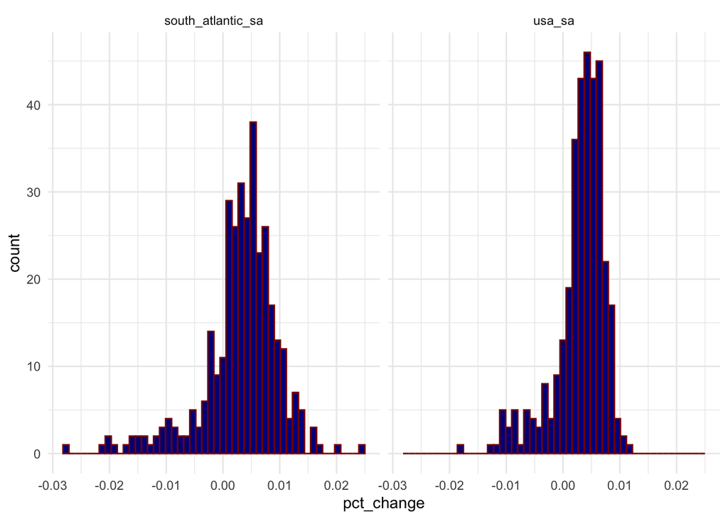

```r
hpi_pct <-
  hpi_tidy %>%
  mutate(pct_change = (hpi / lag(hpi)) - 1,
         pct_change_12_mons = (hpi / lag(hpi, 12)) - 1) %>%
  na.omit()

hpi_pct %>%
  ggplot(aes(x = pct_change)) +
  geom_histogram(fill = "darkblue", color = "darkred", bins = 50) +
  facet_wrap(~division) +
  theme(axis.text.x = element_text(angle = 90, hjust = 1, vjust = 0.5)) +
  theme_minimal()
```

## Analysis details

[^1]: http://www.aaronsw.com/weblog/001189
[^2]: this is a footnote